# 回归验证

HD

2025-03-22

唾液因子：0 1 2 16 4 血清因子：0 1 2

```r
library(dplyr)
```

```r
library(readxl)
library(ggplot2)
```

```r
rm(list=ls())

data <- read_excel("../data/eight.xlsx", col_names = TRUE, row.names(TRUE) )
```

```r
tuoye <- c("MCP1_t", "TNFa_t", "CASP1_t", "GM_CSF_t", "CTSK_t")  # 唾液因子
xueqing <- c("MCP1_x", "TNFa_x", "CASP1_x")  # 血清因子
targets <- c("BVTV", "Tb.Sp", "M1")  # 目标变量
```

```r
evaluate_model <- function(model, data, target) {
  predictions <- predict(model, newdata = data)
  actuals <- data[[target]]
  mse <- mean((predictions - actuals)^2)
  r2 <- summary(model)$r.squared
  return(c(MSE = mse, R2 = r2))
}

# 结果存储
results <- data.frame(Model = character(), Target = character(), MSE = numeric(), R2 = numeric())
```

```r
for (target in targets) {

  # 唾液因子建模
  model_saliva <- lm(as.formula(paste(target, "~", paste(tuoye, collapse = " + "))), data = data)
  res_saliva <- evaluate_model(model_saliva, data, target)
  results <- rbind(results, data.frame(Model = "tuoye", Target = target, MSE = res_saliva["MSE"], R2 = res_saliva["R2"]))

  # 血清因子建模
  model_serum <- lm(as.formula(paste(target, "~", paste(xueqing, collapse = " + "))), data = data)
  res_serum <- evaluate_model(model_serum, data, target)
  results <- rbind(results, data.frame(Model = "xueqing", Target = target, MSE = res_serum["MSE"], R2 = res_serum["R2"]))

  # 合并因子建模
  all_factors <- c(tuoye, xueqing)
  model_combined <- lm(as.formula(paste(target, "~", paste(all_factors, collapse = " + "))), data = data)
  res_combined <- evaluate_model(model_combined, data, target)
  results <- rbind(results, data.frame(Model = "Combined", Target = target, MSE = res_combined["MSE"], R2 = res_combined["R2"]))
}

# 输出结果
print(results)
```

```
##         Model Target         MSE        R2
## MSE     tuoye   BVTV 0.001313449 0.1415814
## MSE1  xueqing   BVTV 0.000929063 0.3928010
## MSE2 Combined   BVTV 0.000764028 0.5006613
## MSE3    tuoye  Tb.Sp 0.005619196 0.8202705
## MSE4  xueqing  Tb.Sp 0.001515288 0.9515336
## MSE5 Combined  Tb.Sp 0.001269091 0.9594082
## MSE6    tuoye     M1 0.052879734 0.7458871
## MSE7  xueqing     M1 0.065003104 0.6876284
## MSE8 Combined     M1 0.048114663 0.7687856
```

```r
write.csv(results, "../result/results.csv")
```

单独使用血清因子（xueqing）比唾液因子（tuoye）表现更好（MSE更低，R²更高），特别是在 BV/TV 和 Tb.Sp 上：

BV/TV: 血清因子的 R² = 0.39，高于唾液因子的 0.14 Tb.Sp: 血清因子的 R² = 0.95，远高于唾液因子的 0.82 但 M1 的 R² 反而是唾液因子更高 (0.75 vs 0.69)，可能说明 M1 变量与唾液因子的关系更强 合并因子（Combined）后整体预测效果提升：

所有目标变量的 MSE 都降低了，R² 也提高了 特别是 BV/TV（R² 提升到 0.50）和 Tb.Sp（R² 提升到 0.96） 结论 血清因子在 BV/TV 和 Tb.Sp 预测能力更强 唾液因子在 M1 上可能更有价值 合并因子后预测效果总体最好，所以建议使用联合模型来提升预测能力

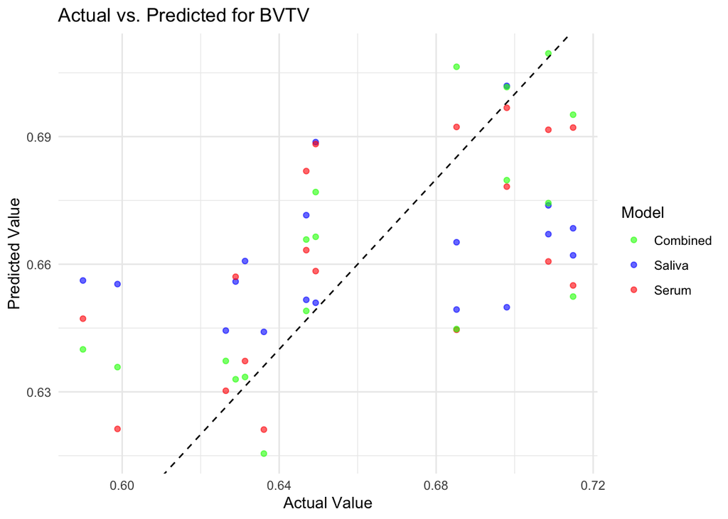

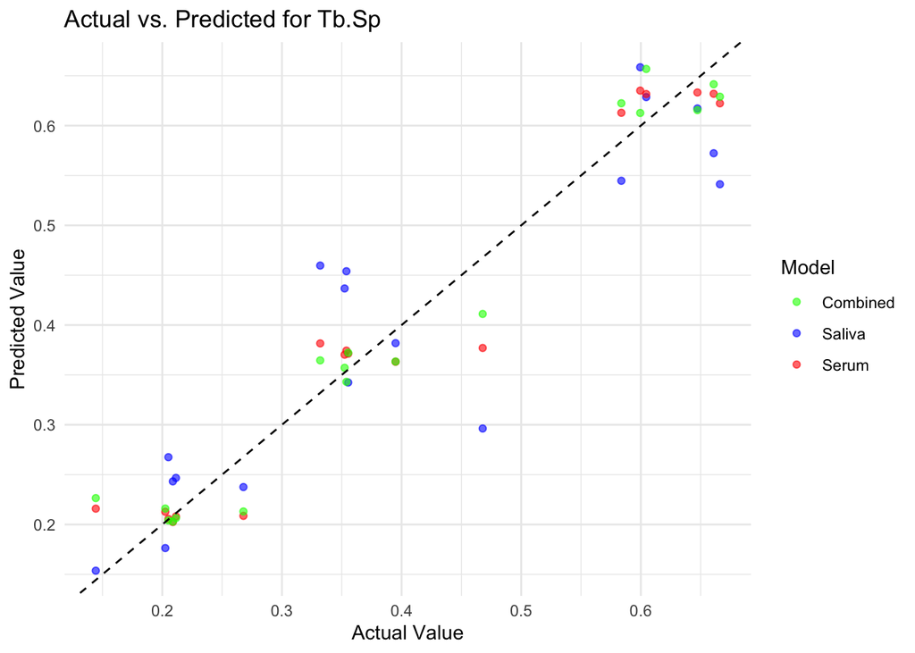

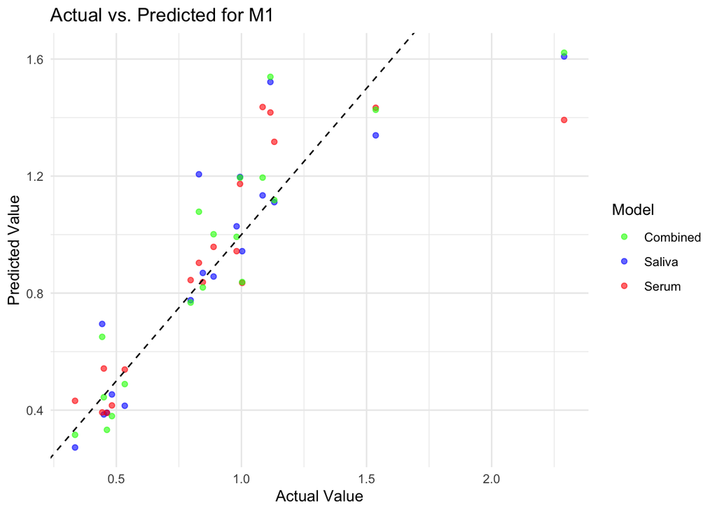

```r
# 预测值计算函数
get_predictions <- function(model, data, target) {
  data.frame(Actual = data[[target]], Predicted = predict(model, newdata = data))
}

# 创建空列表存储预测结果
predictions_list <- list()

# 逐个目标变量绘制散点图
for (target in targets) {

  # 建立回归模型
  model_saliva <- lm(as.formula(paste(target, "~", paste(tuoye, collapse = " + "))), data = data)
  model_serum <- lm(as.formula(paste(target, "~", paste(xueqing, collapse = " + "))), data = data)
  model_combined <- lm(as.formula(paste(target, "~", paste(c(tuoye, xueqing), collapse = " + "))), data = data)

  # 获取预测值
  pred_saliva <- get_predictions(model_saliva, data, target)
  pred_serum <- get_predictions(model_serum, data, target)
  pred_combined <- get_predictions(model_combined, data, target)

  # 添加模型标签
  pred_saliva$Model <- "Saliva"
  pred_serum$Model <- "Serum"
  pred_combined$Model <- "Combined"

  # 合并数据
  pred_all <- rbind(pred_saliva, pred_serum, pred_combined)
  pred_all$Target <- target

  # 存入列表
  predictions_list[[target]] <- pred_all

  # 画散点图
  p <- ggplot(pred_all, aes(x = Actual, y = Predicted, color = Model)) +
    geom_point(alpha = 0.6) +
    geom_abline(slope = 1, intercept = 0, linetype = "dashed") +
    theme_minimal() +
    labs(title = paste("Actual vs. Predicted for", target), x = "Actual Value", y = "Predicted Value") +
    scale_color_manual(values = c("Saliva" = "blue", "Serum" = "red", "Combined" = "green"))

  print(p)
}
```

保存图片

```r
# 设置保存目录（可修改）
output_dir <- "../visulization/"  # 这里替换成你的实际路径

# 逐个目标变量保存图片
for (target in names(predictions_list)) {

  # 获取对应的数据
  pred_all <- predictions_list[[target]]

  # 画图
  p <- ggplot(pred_all, aes(x = Actual, y = Predicted, color = Model)) +
    geom_point(alpha = 0.6) +
    geom_abline(slope = 1, intercept = 0, linetype = "dashed") +
    theme_minimal() +
    theme_bw() +  # 设置白色背景
    labs(title = paste("Actual vs. Predicted for", target), x = "Actual Value", y = "Predicted Value") +
    scale_color_manual(values = c("Saliva" = "blue", "Serum" = "red", "Combined" = "green"))

  # 保存图片
  file_name <- paste0(output_dir, "Actual_vs_Predicted_", target, ".png")
  ggsave(file_name, plot = p, width = 6, height = 5, dpi = 300)
}
```

```r
tuoye_top3 <- c("MCP1_t", "TNFa_t", "CASP1_t")  # 唾液因子
tuoye_top1 <- c("MCP1_t")  # 唾液因子


xueqing_top3 <- c("MCP1_t", "TNFa_t", "CASP1_t")  # 唾液因子
xueqing_top1 <- c("MCP1_t")  # 唾液因子

targets <- c("BVTV", "Tb.Sp", "M1")  # 目标变量
```

```r
evaluate_model <- function(model, data, target) {
  predictions <- predict(model, newdata = data)
  actuals <- data[[target]]
  mse <- mean((predictions - actuals)^2)
  r2 <- summary(model)$r.squared
  return(c(MSE = mse, R2 = r2))
}

# 结果存储
results_2 <- data.frame(Model = character(), Target = character(), MSE = numeric(), R2 = numeric())
```

```r
for (target in targets) {

  # 唾液top3建模
  model_saliva_top3 <- lm(as.formula(paste(target, "~", paste(tuoye_top3, collapse = " + "))), data = data)
  res_saliva_top3 <- evaluate_model(model_saliva_top3, data, target)
  results_2 <- rbind(results, data.frame(Model = "model_saliva_top3", Target = target, MSE = res_saliva_top3["MSE"], R2 = res_saliva_top3["R2"]))

  # 唾液top1建模
  model_saliva_top1 <- lm(as.formula(paste(target, "~", paste(tuoye_top1, collapse = " + "))), data = data)
  res_saliva_top1 <- evaluate_model(model_saliva_top1, data, target)
  results_2 <- rbind(results, data.frame(Model = "model_saliva_top1", Target = target, MSE = res_saliva_top1["MSE"], R2 = res_saliva_top1["R2"]))

  # 血清top3建模
  model_serum_top3 <- lm(as.formula(paste(target, "~", paste(xueqing_top3, collapse = " + "))), data = data)
  res_serum_top3 <- evaluate_model(model_serum_top3, data, target)
  results_2 <- rbind(results, data.frame(Model = "model_serum_top3", Target = target, MSE = res_serum_top3["MSE"], R2 = res_serum_top3["R2"]))

  # 血清top1建模
  model_serum_top1 <- lm(as.formula(paste(target, "~", paste(xueqing_top1, collapse = " + "))), data = data)
  res_serum_top1 <- evaluate_model(model_serum_top1, data, target)
  results_2 <- rbind(results, data.frame(Model = "model_serum_top1", Target = target, MSE = res_serum_top1["MSE"], R2 = res_serum_top1["R2"]))

}

# 输出结果
print(results_2)
```

```
##                 Model Target         MSE        R2
## MSE             tuoye   BVTV 0.001313449 0.1415814
## MSE1          xueqing   BVTV 0.000929063 0.3928010
## MSE2         Combined   BVTV 0.000764028 0.5006613
## MSE3            tuoye  Tb.Sp 0.005619196 0.8202705
## MSE4          xueqing  Tb.Sp 0.001515288 0.9515336
## MSE5         Combined  Tb.Sp 0.001269091 0.9594082
## MSE6            tuoye     M1 0.052879734 0.7458871
## MSE7          xueqing     M1 0.065003104 0.6876284
## MSE8         Combined     M1 0.048114663 0.7687856
## MSE9 model_serum_top1     M1 0.065878578 0.6834213
```

```r
write.csv(results_2, "../result/results_3vs1.csv")
```